# Project 2: SWAC Football Recruitment Analysis

**Advanced Analysis of SWAC Football Player Recruitment Patterns**

This notebook analyzes the cleaned SWAC football recruitment dataset to identify patterns in player recruitment, state origins, and high school data coverage.

## Overview

- **Dataset**: SWAC_rosters_clean.csv (15,571 players, 2010-2025)
- **Quality**: 99.46% player state completion, 74.4% high school coverage
- **Teams**: 12 SWAC football programs
- **Purpose**: Comprehensive recruitment pattern analysis

## Analysis Goals

1. Examine player recruitment patterns by state
2. Analyze high school data coverage and quality
3. Identify team-specific recruitment strategies
4. Investigate temporal trends in recruitment over seasons

```python
# ===== SECTION 1: IMPORT REQUIRED LIBRARIES =====

import pandas as pd
import numpy as np
import matplotlib.pyplot as plt
import seaborn as sns
import warnings
from pathlib import Path

# Set display options for better output formatting
pd.set_option('display.max_columns', None)
pd.set_option('display.width', None)
pd.set_option('display.max_colwidth', 50)

# Configure matplotlib and seaborn
plt.style.use('default')
sns.set_palette("husl")
warnings.filterwarnings('ignore')
```

## Data Exploration

#### In the next few code chunks, we want to make sure our cleaned data set possesses the coverage we want. We run msisingness checks for the most important variables in our data.

```python
# ===== SECTION 2: LOAD CLEANED SWAC DATASET =====

# Define the path to the cleaned dataset
dataset_path = r"C:\Users\jland\OneDrive\Emory Essentials\Research\College Football Output\SWAC Rosters2\SWAC_rosters_clean.csv"

print("📥 Loading cleaned SWAC football recruitment dataset...")
print(f"   📁 Path: {dataset_path}")

try:
    # Load the cleaned dataset
    swac_data = pd.read_csv(dataset_path)

    print("✅ Dataset loaded successfully!")
    print(f"   📊 Shape: {swac_data.shape[0]:,} rows × {swac_data.shape[1]} columns")
    print(f"   📅 Time period: {swac_data['season'].min()}-{swac_data['season'].max()}")
    print(f"   🏫 Teams: {swac_data['team'].nunique()} SWAC programs")

    # Display basic dataset information
    print(f"\n📋 Dataset Columns:")
    for i, col in enumerate(swac_data.columns, 1):
        print(f"   {i:2d}. {col}")

    # Show data types
    print(f"\n🔍 Data Types:")
    print(swac_data.dtypes.to_string())

except FileNotFoundError:
    print("❌ Error: Could not find the cleaned dataset file")
    print("   Please ensure the file path is correct and the file exists")
except Exception as e:
    print(f"❌ Error loading dataset: {str(e)}")
```

```
📥 Loading cleaned SWAC football recruitment dataset...
   📁 Path: C:\Users\jland\OneDrive\Emory Essentials\Research\College Football Output\SWAC Rosters2\SWAC_rosters_clean.csv
✅ Dataset loaded successfully!
   📊 Shape: 15,571 rows × 10 columns
   📅 Time period: 2010-2025
   🏫 Teams: 12 SWAC programs

📋 Dataset Columns:
    1. team
    2. season
    3. name
    4. high_school
    5. hometown
    6. previous_school
    7. class
    8. team_state
    9. player_state
   10. is_international

🔍 Data Types:
team                object
season               int64
name                object
high_school         object
hometown            object
previous_school     object
class               object
team_state          object
player_state        object
is_international      bool
```

```python
# ===== SECTION 3: INITIAL DATA EXPLORATION =====

print("🔍 INITIAL DATA EXPLORATION")
print("=" * 40)

# Display first few rows
print("📋 First 10 rows of the dataset:")
display(swac_data.head(10))

print(f"\n📊 Dataset Overview:")
print(f"   Total players: {len(swac_data):,}")
print(f"   Unique teams: {swac_data['team'].nunique()}")
print(f"   Season range: {swac_data['season'].min()}-{swac_data['season'].max()}")
print(f"   Unique players (by name): {swac_data['name'].nunique():,}")

# Check for missing values
print(f"\n❓ Missing Values Analysis:")
missing_data = swac_data.isnull().sum()
total_rows = len(swac_data)

for column in swac_data.columns:
    missing_count = missing_data[column]
    missing_pct = (missing_count / total_rows) * 100
    if missing_count > 0:
        print(f"   {column:20s}: {missing_count:5,} missing ({missing_pct:5.1f}%)")
    else:
        print(f"   {column:20s}: ✅ Complete")

# Examine unique values in key columns
print(f"\n🏫 SWAC Teams in Dataset:")
team_counts = swac_data['team'].value_counts().sort_values(ascending=False)
for team, count in team_counts.items():
    percentage = (count / len(swac_data)) * 100
    print(f"   {team:25s}: {count:5,} players ({percentage:4.1f}%)")

print(f"\n📅 Seasons Covered:")
season_counts = swac_data['season'].value_counts().sort_index()
for season, count in season_counts.items():
    print(f"   {season}: {count:,} players")

print(f"\n🗺️ Top 10 States by Player Count:")
if 'player_state' in swac_data.columns:
    state_counts = swac_data['player_state'].value_counts().head(10)
    for state, count in state_counts.items():
        percentage = (count / len(swac_data)) * 100
        state_display = 'International' if state == 'INTL' else state
        print(f"   {state_display:15s}: {count:5,} players ({percentage:4.1f}%)")
```

```
🔍 INITIAL DATA EXPLORATION
========================================
📋 First 10 rows of the dataset:
```

|  | team | season | name | high_school | hometown | previous_school | class | team_state | player_state | is_international |
| --- | --- | --- | --- | --- | --- | --- | --- | --- | --- | --- |
| 0 | Jackson State | 2025 | Travis Terrell Jr. | Creekside HS | Atlanta, Ga. | NaN | So. | MS | GA | False |
| 1 | Jackson State | 2025 | Jeremiah Williams | Holmes County Central HS | Lexington, Miss. | NaN | R-Sr. | MS | MS | False |
| 2 | Jackson State | 2025 | Khamauri Rogers | Holmes County Central HS | Madison, Miss. | Mississippi State | Gr. | MS | MS | False |
| 3 | Jackson State | 2025 | Shemar Savage | Lompoc HS | Lompoc, Calif. | Prairie View A&M | Gr. | MS | CA | False |
| 4 | Jackson State | 2025 | Ja'Naylon Dupree | Neshoba Central HS | Philadelphia, Miss. | Mississippi Gulf Coast CC | Sr. | MS | MS | False |
| 5 | Jackson State | 2025 | Levi Wyatt | Holmes County Central HS | Vicksburg, Miss. | McNeese State | Sr. | MS | MS | False |
| 6 | Jackson State | 2025 | Nate Rembert | Eustis HS | Eustis, Fla. | Mississippi Valley State | Jr. | MS | FL | False |
| 7 | Jackson State | 2025 | Ashton Taylor | Hoover HS | Hoover, Ala. | Tennessee Tech | R-Jr. | MS | AL | False |
| 8 | Jackson State | 2025 | Tyquan Henderson | Canton HS | Canton, Miss. | Southern Miss | Gr. | MS | MS | False |
| 9 | Jackson State | 2025 | Mike Smith III | Trotwood-Mason HS | Dayton, Ohio | NaN | So. | MS | OH | False |

```
📊 Dataset Overview:
   Total players: 15,571
   Unique teams: 12
   Season range: 2010-2025
   Unique players (by name): 7,682

❓ Missing Values Analysis:
   team                : ✅ Complete
   season              : ✅ Complete
   name                :    91 missing (  0.6%)
   high_school         : 3,986 missing ( 25.6%)
   hometown            :    73 missing (  0.5%)
   previous_school     : 12,414 missing ( 79.7%)
   class               :     2 missing (  0.0%)
   team_state          : ✅ Complete
   player_state        :    84 missing (  0.5%)
   is_international    : ✅ Complete

🏫 SWAC Teams in Dataset:
   Alabama State            : 1,588 players (10.2%)
   Florida A&M              : 1,508 players ( 9.7%)
   Prairie View A&M         : 1,481 players ( 9.5%)
   Bethune-Cookman          : 1,455 players ( 9.3%)
   Grambling                : 1,387 players ( 8.9%)
   Texas Southern           : 1,334 players ( 8.6%)
   Southern                 : 1,313 players ( 8.4%)
   Alcorn State             : 1,295 players ( 8.3%)
   Alabama A&M              : 1,203 players ( 7.7%)
   UAPB                     : 1,171 players ( 7.5%)
   Mississippi Valley State : 1,090 players ( 7.0%)
   Jackson State            :   746 players ( 4.8%)

📅 Seasons Covered:
   2010: 552 players
   2011: 627 players
   2012: 930 players
   2013: 848 players
   2014: 860 players
   2015: 883 players
   2016: 939 players
   2017: 964 players
   2018: 1,090 players
   2019: 1,030 players
   2020: 771 players
   2021: 1,201 players
   2022: 1,227 players
   2023: 1,236 players
   2024: 1,211 players
   2025: 1,202 players

🗺️ Top 10 States by Player Count:
   FL             : 3,462 players (22.2%)
   TX             : 2,664 players (17.1%)
   LA             : 2,129 players (13.7%)
   AL             : 1,532 players ( 9.8%)
   MS             : 1,427 players ( 9.2%)
   GA             : 1,224 players ( 7.9%)
   CA             :   471 players ( 3.0%)
   TN             :   382 players ( 2.5%)
   AR             :   378 players ( 2.4%)
   IL             :   223 players ( 1.4%)
```

```python
# ===== SECTION 4: DATA QUALITY VERIFICATION =====

print("🎯 DATA QUALITY VERIFICATION")
print("=" * 35)

# Verify player state assignment success rate
if 'player_state' in swac_data.columns:
    total_players = len(swac_data)
    players_with_state = swac_data['player_state'].notna().sum()
    missing_states = total_players - players_with_state
    state_success_rate = (players_with_state / total_players) * 100

    print(f"🗺️ PLAYER STATE ASSIGNMENTS:")
    print(f"   ✅ Successfully assigned: {players_with_state:,} players")
    print(f"   ❌ Missing assignments: {missing_states:,} players")
    print(f"   📈 Success rate: {state_success_rate:.2f}%")

    # Check for international players
    intl_players = (swac_data['player_state'] == 'INTL').sum()
    print(f"   🌍 International players: {intl_players:,}")

    # Verify target achievement
    target_rate = 99.36
    if state_success_rate >= target_rate:
        print(f"   🎉 SUCCESS! Exceeds {target_rate}% target by {state_success_rate - target_rate:.2f} points")
    else:
        print(f"   ⚠️ Below {target_rate}% target by {target_rate - state_success_rate:.2f} points")

# Verify high school data coverage
if 'high_school' in swac_data.columns:
    total_players = len(swac_data)
    players_with_hs = swac_data['high_school'].notna().sum()
    missing_hs = total_players - players_with_hs
    hs_coverage_rate = (players_with_hs / total_players) * 100

    print(f"\n🏫 HIGH SCHOOL DATA COVERAGE:")
    print(f"   ✅ With high school data: {players_with_hs:,} players")
    print(f"   ❌ Missing high school data: {missing_hs:,} players")
    print(f"   📈 Coverage rate: {hs_coverage_rate:.1f}%")

# Verify team state mappings
if 'team_state' in swac_data.columns:
    team_state_coverage = swac_data['team_state'].notna().sum()
    team_state_rate = (team_state_coverage / total_players) * 100

    print(f"\n🏛️ TEAM STATE MAPPINGS:")
    print(f"   ✅ Complete mappings: {team_state_coverage:,} players")
    print(f"   📈 Coverage rate: {team_state_rate:.1f}%")

# Overall data completeness summary
print(f"\n📊 OVERALL DATA COMPLETENESS:")
completeness_scores = []

for column in ['player_state', 'high_school', 'team_state', 'hometown']:
    if column in swac_data.columns:
        complete_count = swac_data[column].notna().sum()
        completeness_pct = (complete_count / total_players) * 100
        completeness_scores.append(completeness_pct)
        status = "✅ Excellent" if completeness_pct >= 90 else "⚠️ Good" if completeness_pct >= 70 else "❌ Needs Improvement"
        print(f"   {column:15s}: {completeness_pct:5.1f}% {status}")

if completeness_scores:
    avg_completeness = np.mean(completeness_scores)
    print(f"\n   📈 Average completeness: {avg_completeness:.1f}%")

print(f"\n🎉 DATA QUALITY VERIFICATION COMPLETE!")
print(f"Dataset is ready for comprehensive recruitment pattern analysis!")
```

```
🎯 DATA QUALITY VERIFICATION
===================================
🗺️ PLAYER STATE ASSIGNMENTS:
   ✅ Successfully assigned: 15,487 players
   ❌ Missing assignments: 84 players
   📈 Success rate: 99.46%
   🌍 International players: 109
   🎉 SUCCESS! Exceeds 99.36% target by 0.10 points

🏫 HIGH SCHOOL DATA COVERAGE:
   ✅ With high school data: 11,585 players
   ❌ Missing high school data: 3,986 players
   📈 Coverage rate: 74.4%

🏛️ TEAM STATE MAPPINGS:
   ✅ Complete mappings: 15,571 players
   📈 Coverage rate: 100.0%

📊 OVERALL DATA COMPLETENESS:
   player_state   :  99.5% ✅ Excellent
   high_school    :  74.4% ⚠️ Good
   team_state     : 100.0% ✅ Excellent
   hometown       :  99.5% ✅ Excellent

   📈 Average completeness: 93.3%

🎉 DATA QUALITY VERIFICATION COMPLETE!
Dataset is ready for comprehensive recruitment pattern analysis!
```

## In-State Recruitment Analysis

#### In this code chunk, we're interested in learning how often schools recruit in-state athletes. In college football, in-state recruiting, especially in the South, is considered crucial to program success. In talent-rich areas, building a roster from mostly in-state recruits can positively affect retention, fan attendance, and team culture. For these resaons, it's important to know which teams rely mostly on in-state recruiting. At HBCUs in particular, recruiting budgets are slim, so building rosters that are in-state add additional financial value. In-state players have scholarships that are cheaper and it costs less to travel to recruit them.

#### Looking at the data, it makes that schools in two of the most talnet-rich states in football -- Texas and Florida -- have the highest rates of in-state players.FAMU, BCU, PVAMU, and TSU are well above average for the SWAC.

#### This information can be vastly important for athletic departments to be aware of when advising football coaches either on staff or potential candidates. Both coaches and athletic departments can know where they stand in terms of in-state recruiting and whether to prioritize or de-prioritze based on relative performance.

```
🏠 IN-STATE RECRUITMENT ANALYSIS
========================================
   Alabama A&M              : 546/1203 =  45.4% in-state
   Alabama State            : 563/1588 =  35.5% in-state
   Alcorn State             : 502/1295 =  38.8% in-state
   Bethune-Cookman          : 1051/1455 =  72.2% in-state
   Florida A&M              : 1140/1508 =  75.6% in-state
   Grambling                : 652/1387 =  47.0% in-state
   Jackson State            : 248/ 746 =  33.2% in-state
   Mississippi Valley State : 380/1090 =  34.9% in-state
   Prairie View A&M         : 915/1481 =  61.8% in-state
   Southern                 : 683/1313 =  52.0% in-state
   Texas Southern           : 846/1334 =  63.4% in-state
   UAPB                     : 309/1171 =  26.4% in-state
```

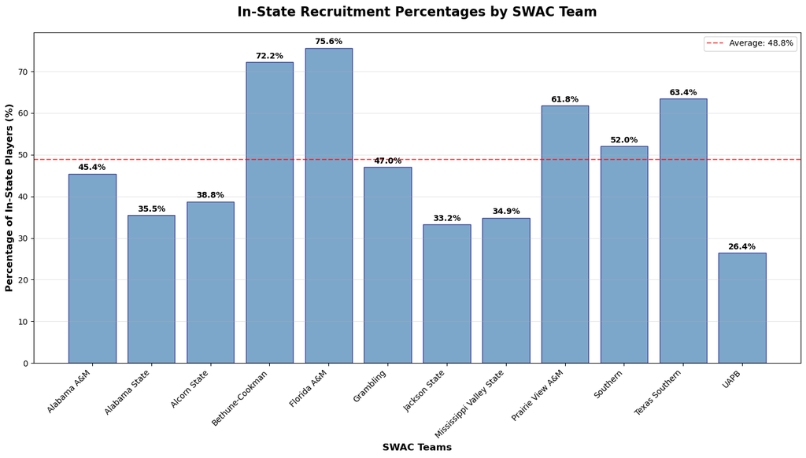

```
📊 IN-STATE RECRUITMENT SUMMARY:
   🏆 Highest in-state recruitment: Florida A&M (75.6%)
   📉 Lowest in-state recruitment: UAPB (26.4%)
   📈 Average in-state recruitment: 48.8%
   📊 Median in-state recruitment: 46.2%
```

```python
# ===== SECTION 5: IN-STATE RECRUITMENT ANALYSIS =====

print("🏠 IN-STATE RECRUITMENT ANALYSIS")
print("=" * 40)

# Calculate in-state recruitment percentages for each team
in_state_recruitment = []

for team in sorted(swac_data['team'].unique()):
    team_data = swac_data[swac_data['team'] == team]

    # Count total players for this team
    total_players = len(team_data)

    # Count players where player_state equals team_state (in-state recruits)
    in_state_players = len(team_data[
        (team_data['player_state'] == team_data['team_state']) &
        (team_data['player_state'].notna()) &
        (team_data['team_state'].notna())
    ])

    # Calculate percentage
    in_state_percentage = (in_state_players / total_players * 100) if total_players > 0 else 0

    in_state_recruitment.append({
        'team': team,
        'total_players': total_players,
        'in_state_players': in_state_players,
        'in_state_percentage': in_state_percentage
    })

    print(f"   {team:25s}: {in_state_players:3d}/{total_players:4d} = {in_state_percentage:5.1f}% in-state")

# Create DataFrame for plotting
recruitment_df = pd.DataFrame(in_state_recruitment)

# Create the bar graph
plt.figure(figsize=(14, 8))
bars = plt.bar(recruitment_df['team'], recruitment_df['in_state_percentage'],
               color='steelblue', alpha=0.7, edgecolor='navy', linewidth=1)

# Customize the plot
plt.title('In-State Recruitment Percentages by SWAC Team',
          fontsize=16, fontweight='bold', pad=20)
plt.xlabel('SWAC Teams', fontsize=12, fontweight='bold')
plt.ylabel('Percentage of In-State Players (%)', fontsize=12, fontweight='bold')

# Rotate x-axis labels for better readability
plt.xticks(rotation=45, ha='right')

# Add percentage labels on top of each bar
for bar, percentage in zip(bars, recruitment_df['in_state_percentage']):
    plt.text(bar.get_x() + bar.get_width()/2, bar.get_height() + 0.5,
             f'{percentage:.1f}%', ha='center', va='bottom', fontweight='bold')

# Add a horizontal line for average
avg_in_state = recruitment_df['in_state_percentage'].mean()
plt.axhline(y=avg_in_state, color='red', linestyle='--', alpha=0.7,
            label=f'Average: {avg_in_state:.1f}%')

# Add grid for better readability
plt.grid(axis='y', alpha=0.3)

# Add legend
plt.legend()

# Adjust layout to prevent label cutoff
plt.tight_layout()

# Show the plot
plt.show()

# Summary statistics
print(f"\n📊 IN-STATE RECRUITMENT SUMMARY:")
print(f"   🏆 Highest in-state recruitment: {recruitment_df.loc[recruitment_df['in_state_percentage'].idxmax(), 'team']} ({recruitment_df['in_state_percentage'].max():.1f}%)")
print(f"   📉 Lowest in-state recruitment: {recruitment_df.loc[recruitment_df['in_state_percentage'].idxmin(), 'team']} ({recruitment_df['in_state_percentage'].min():.1f}%)")
print(f"   📈 Average in-state recruitment: {avg_in_state:.1f}%")
print(f"   📊 Median in-state recruitment: {recruitment_df['in_state_percentage'].median():.1f}%")
```

## In-State Recruiting = Football Success?

```
🐅 JACKSON STATE IN-STATE RECRUITMENT TRENDS
==================================================
📊 Jackson State dataset: 746 players across 8 seasons
   2018: 45/ 90 =  50.0% Mississippi players
   2019: 38/ 83 =  45.8% Mississippi players
   2020: 37/ 83 =  44.6% Mississippi players
   2021: 26/ 94 =  27.7% Mississippi players
   2022: 11/ 95 =  11.6% Mississippi players
   2023: 28/105 =  26.7% Mississippi players
   2024: 28/101 =  27.7% Mississippi players
   2025: 35/ 95 =  36.8% Mississippi players
```

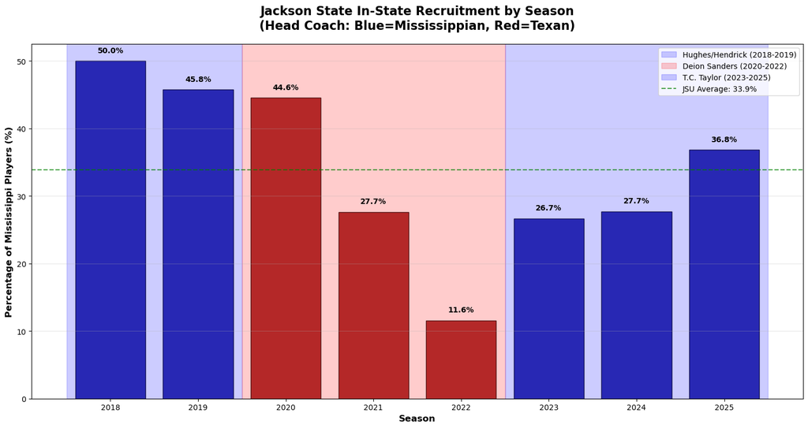

```
📈 COACHING ERA ANALYSIS:
   🔵 Hughes/Hendrick & T.C. Taylor Average: 37.4%
   🔴 Deion Sanders Average: 27.9%

   📊 Overall JSU Average: 33.9%
   📈 Highest in-state recruitment: 50.0% (Season 2018)
   📉 Lowest in-state recruitment: 11.6% (Season 2022)
```

```python
# ===== SECTION 6: JACKSON STATE IN-STATE RECRUITMENT BY SEASON =====

print("🐅 JACKSON STATE IN-STATE RECRUITMENT TRENDS")
print("=" * 50)

# Filter data for Jackson State only
jsu_data = swac_data[swac_data['team'] == 'Jackson State'].copy()

print(f"📊 Jackson State dataset: {len(jsu_data):,} players across {jsu_data['season'].nunique()} seasons")

# Calculate in-state recruitment percentages by season for JSU
jsu_by_season = []

for season in sorted(jsu_data['season'].unique()):
    season_data = jsu_data[jsu_data['season'] == season]

    # Count total players for this season
    total_players = len(season_data)

    # Count players where player_state equals team_state (Mississippi players)
    in_state_players = len(season_data[
        (season_data['player_state'] == season_data['team_state']) &
        (season_data['player_state'].notna()) &
        (season_data['team_state'].notna())
    ])

    # Calculate percentage
    in_state_percentage = (in_state_players / total_players * 100) if total_players > 0 else 0

    jsu_by_season.append({
        'season': season,
        'total_players': total_players,
        'in_state_players': in_state_players,
        'in_state_percentage': in_state_percentage
    })

    print(f"   {season}: {in_state_players:2d}/{total_players:3d} = {in_state_percentage:5.1f}% Mississippi players")

# Create DataFrame for plotting
jsu_season_df = pd.DataFrame(jsu_by_season)

# Create the bar graph
plt.figure(figsize=(15, 8))

# Color bars differently based on head coach origin
colors = []
for season in jsu_season_df['season']:
    if season in [2018, 2019, 2023, 2024, 2025]:
        colors.append('darkblue')  # Mississippian head coach
    elif season in [2020, 2021, 2022]:
        colors.append('darkred')   # Texas head coach
    else:
        colors.append('gray')      # Other/unknown

bars = plt.bar(jsu_season_df['season'], jsu_season_df['in_state_percentage'],
               color=colors, alpha=0.8, edgecolor='black', linewidth=1)

# Customize the plot
plt.title('Jackson State In-State Recruitment by Season\n(Head Coach: Blue=Mississippian, Red=Texan)',
          fontsize=16, fontweight='bold', pad=20)
plt.xlabel('Season', fontsize=12, fontweight='bold')
plt.ylabel('Percentage of Mississippi Players (%)', fontsize=12, fontweight='bold')

# Add percentage labels on top of each bar
for bar, row in zip(bars, jsu_season_df.itertuples()):
    plt.text(bar.get_x() + bar.get_width()/2, bar.get_height() + 1,
             f'{row.in_state_percentage:.1f}%', ha='center', va='bottom', fontweight='bold')

# Add annotations for coaching changes
plt.axvspan(2017.5, 2019.5, alpha=0.2, color='blue', label='Hughes/Hendrick (2018-2019)')
plt.axvspan(2019.5, 2022.5, alpha=0.2, color='red', label='Deion Sanders (2020-2022)')
plt.axvspan(2022.5, 2025.5, alpha=0.2, color='blue', label='T.C. Taylor (2023-2025)')

# Add horizontal line for JSU's overall average
jsu_avg = jsu_season_df['in_state_percentage'].mean()
plt.axhline(y=jsu_avg, color='green', linestyle='--', alpha=0.7,
            label=f'JSU Average: {jsu_avg:.1f}%')

# Add grid for better readability
plt.grid(axis='y', alpha=0.3)

# Add legend
plt.legend(loc='upper right')

# Set x-axis to show all years
plt.xticks(jsu_season_df['season'])

# Adjust layout
plt.tight_layout()

# Show the plot
plt.show()

# Analysis by coaching era
print(f"\n📈 COACHING ERA ANALYSIS:")

# Mississippian HC periods (2018-2019, 2023-2025)
ms_coach_seasons = jsu_season_df[jsu_season_df['season'].isin([2018, 2019, 2023, 2024, 2025])]
if len(ms_coach_seasons) > 0:
    ms_avg = ms_coach_seasons['in_state_percentage'].mean()
    print(f"   🔵 Hughes/Hendrick & T.C. Taylor Average: {ms_avg:.1f}%")

# Texas HC period (2020-2022)
tx_coach_seasons = jsu_season_df[jsu_season_df['season'].isin([2020, 2021, 2022])]
if len(tx_coach_seasons) > 0:
    tx_avg = tx_coach_seasons['in_state_percentage'].mean()
    print(f"   🔴 Deion Sanders Average: {tx_avg:.1f}%")

# Other seasons
other_seasons = jsu_season_df[~jsu_season_df['season'].isin([2018, 2019, 2020, 2021, 2022, 2023, 2024, 2025])]
if len(other_seasons) > 0:
    other_avg = other_seasons['in_state_percentage'].mean()
    print(f"   ⚪ Other Seasons Average: {other_avg:.1f}%")

print(f"\n   📊 Overall JSU Average: {jsu_avg:.1f}%")

# Show range of values
print(f"   📈 Highest in-state recruitment: {jsu_season_df['in_state_percentage'].max():.1f}% (Season {jsu_season_df.loc[jsu_season_df['in_state_percentage'].idxmax(), 'season']})")
print(f"   📉 Lowest in-state recruitment: {jsu_season_df['in_state_percentage'].min():.1f}% (Season {jsu_season_df.loc[jsu_season_df['in_state_percentage'].idxmin(), 'season']})")
```

## In-State Recruiting: Another Case

#### In this chunk we look at FAMU's recruiting. Unlike JSU, FAMU rosters hover around 70% in-state regardless of coaching regime. Although in-state recruiting remains consistent. Results can be wildly varied. from 2015 to 2017, Alex Wood was head coach who compiled an embarrassing 8-25 overall record. His successor was Willie Simmons, who proved to be one of the best coaches in FAMU history. Simmons compiled a 45-13 overall record at FAMU. His successor is James Colzie, whose overall record sits in between the two of them so far with a 10-9 record. This chart suggests that maintaining a steady proportion of in-state talent can still produced varied results on the field.

```
FLORIDA A&M IN-STATE RECRUITMENT TRENDS
==================================================
📊 Florida A&M dataset: 1,114 players across 11 seasons (2015-2025)
   2015: 67/ 91 =  73.6% Florida players
   2016: 71/ 89 =  79.8% Florida players
   2017: 61/ 78 =  78.2% Florida players
   2018: 61/ 84 =  72.6% Florida players
   2019: 77/101 =  76.2% Florida players
   2020: 76/ 96 =  79.2% Florida players
   2021: 98/126 =  77.8% Florida players
   2022: 87/121 =  71.9% Florida players
   2023: 74/117 =  63.2% Florida players
   2024: 66/104 =  63.5% Florida players
   2025: 78/107 =  72.9% Florida players
```

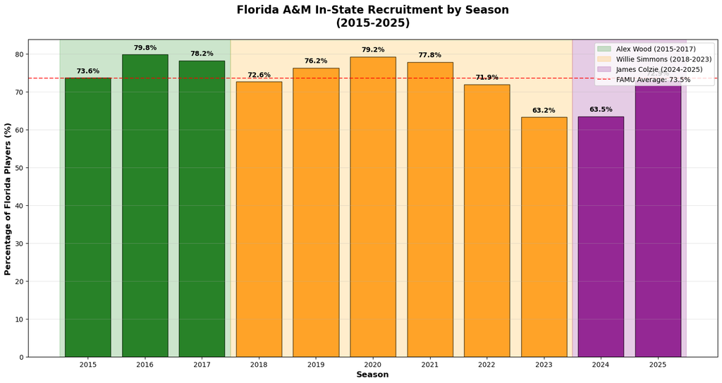

```
📈 COACHING ERA ANALYSIS:
   🟢 Alex Wood Average (2015-2017): 77.2%
   🟠 Willie Simmons Average (2018-2023): 73.5%
   🟣 James Colzie Average (2024-2025): 68.2%

   📊 Overall FAMU Average (2015-2025): 73.5%
   📈 Highest in-state recruitment: 79.8% (Season 2016)
   📉 Lowest in-state recruitment: 63.2% (Season 2023)

🔍 COACHING COMPARISON:
   Alex Wood vs Willie Simmons: +3.7 percentage point difference
   Willie Simmons vs James Colzie: +5.3 percentage point difference
   Alex Wood vs James Colzie: +9.0 percentage point difference
```

```python
# ===== SECTION 7: FLORIDA A&M IN-STATE RECRUITMENT BY SEASON =====

print("FLORIDA A&M IN-STATE RECRUITMENT TRENDS")
print("=" * 50)

# Filter data for Florida A&M only (2015-2025)
famu_data = swac_data[
    (swac_data['team'] == 'Florida A&M') &
    (swac_data['season'] >= 2015) &
    (swac_data['season'] <= 2025)
].copy()

print(f"📊 Florida A&M dataset: {len(famu_data):,} players across {famu_data['season'].nunique()} seasons (2015-2025)")

# Calculate in-state recruitment percentages by season for FAMU
famu_by_season = []

for season in sorted(famu_data['season'].unique()):
    season_data = famu_data[famu_data['season'] == season]

    # Count total players for this season
    total_players = len(season_data)

    # Count players where player_state equals team_state (Florida players)
    in_state_players = len(season_data[
        (season_data['player_state'] == season_data['team_state']) &
        (season_data['player_state'].notna()) &
        (season_data['team_state'].notna())
    ])

    # Calculate percentage
    in_state_percentage = (in_state_players / total_players * 100) if total_players > 0 else 0

    famu_by_season.append({
        'season': season,
        'total_players': total_players,
        'in_state_players': in_state_players,
        'in_state_percentage': in_state_percentage
    })

    print(f"   {season}: {in_state_players:2d}/{total_players:3d} = {in_state_percentage:5.1f}% Florida players")

# Create DataFrame for plotting
famu_season_df = pd.DataFrame(famu_by_season)

# Create the bar graph
plt.figure(figsize=(15, 8))

# Color bars differently based on head coach
colors = []
for season in famu_season_df['season']:
    if season in [2015, 2016, 2017]:
        colors.append('darkgreen')  # Alex Wood
    elif season in [2018, 2019, 2020, 2021, 2022, 2023]:
        colors.append('darkorange')  # Willie Simmons
    elif season in [2024, 2025]:
        colors.append('purple')  # James Colzie
    else:
        colors.append('gray')      # Other/unknown

bars = plt.bar(famu_season_df['season'], famu_season_df['in_state_percentage'],
               color=colors, alpha=0.8, edgecolor='black', linewidth=1)

# Customize the plot
plt.title('Florida A&M In-State Recruitment by Season\n(2015-2025)',
          fontsize=16, fontweight='bold', pad=20)
plt.xlabel('Season', fontsize=12, fontweight='bold')
plt.ylabel('Percentage of Florida Players (%)', fontsize=12, fontweight='bold')

# Add percentage labels on top of each bar
for bar, row in zip(bars, famu_season_df.itertuples()):
    plt.text(bar.get_x() + bar.get_width()/2, bar.get_height() + 1,
             f'{row.in_state_percentage:.1f}%', ha='center', va='bottom', fontweight='bold')

# Add annotations for coaching changes
plt.axvspan(2014.5, 2017.5, alpha=0.2, color='green', label='Alex Wood (2015-2017)')
plt.axvspan(2017.5, 2023.5, alpha=0.2, color='orange', label='Willie Simmons (2018-2023)')
plt.axvspan(2023.5, 2025.5, alpha=0.2, color='purple', label='James Colzie (2024-2025)')

# Add horizontal line for FAMU's overall average
famu_avg = famu_season_df['in_state_percentage'].mean()
plt.axhline(y=famu_avg, color='red', linestyle='--', alpha=0.7,
            label=f'FAMU Average: {famu_avg:.1f}%')

# Add grid for better readability
plt.grid(axis='y', alpha=0.3)

# Add legend
plt.legend(loc='upper right')

# Set x-axis to show all years
plt.xticks(famu_season_df['season'])

# Adjust layout
plt.tight_layout()

# Show the plot
plt.show()

# Analysis by coaching era
print(f"\n📈 COACHING ERA ANALYSIS:")

# Alex Wood period (2015-2017)
wood_seasons = famu_season_df[famu_season_df['season'].isin([2015, 2016, 2017])]
if len(wood_seasons) > 0:
    wood_avg = wood_seasons['in_state_percentage'].mean()
    print(f"   🟢 Alex Wood Average (2015-2017): {wood_avg:.1f}%")

# Willie Simmons period (2018-2023)
simmons_seasons = famu_season_df[famu_season_df['season'].isin([2018, 2019, 2020, 2021, 2022, 2023])]
if len(simmons_seasons) > 0:
    simmons_avg = simmons_seasons['in_state_percentage'].mean()
    print(f"   🟠 Willie Simmons Average (2018-2023): {simmons_avg:.1f}%")

# James Colzie period (2024-2025)
colzie_seasons = famu_season_df[famu_season_df['season'].isin([2024, 2025])]
if len(colzie_seasons) > 0:
    colzie_avg = colzie_seasons['in_state_percentage'].mean()
    print(f"   🟣 James Colzie Average (2024-2025): {colzie_avg:.1f}%")

print(f"\n   📊 Overall FAMU Average (2015-2025): {famu_avg:.1f}%")

# Show range of values
print(f"   📈 Highest in-state recruitment: {famu_season_df['in_state_percentage'].max():.1f}% (Season {famu_season_df.loc[famu_season_df['in_state_percentage'].idxmax(), 'season']})")
print(f"   📉 Lowest in-state recruitment: {famu_season_df['in_state_percentage'].min():.1f}% (Season {famu_season_df.loc[famu_season_df['in_state_percentage'].idxmin(), 'season']})")

# Compare coaching tenures
if len(wood_seasons) > 0 and len(simmons_seasons) > 0 and len(colzie_seasons) > 0:
    print(f"\n🔍 COACHING COMPARISON:")
    print(f"   Alex Wood vs Willie Simmons: {wood_avg - simmons_avg:+.1f} percentage point difference")
    print(f"   Willie Simmons vs James Colzie: {simmons_avg - colzie_avg:+.1f} percentage point difference")
    print(f"   Alex Wood vs James Colzie: {wood_avg - colzie_avg:+.1f} percentage point difference")
```

## Not just "What state?", but "What school?"

#### In my larger research project, I'll be looking into the concentration of elite athletes at private schools. SWAC schools typically recruit 3rd or 4th tier athletes, many of whom still largely come from public schools. Eventually, I'll compare SWAC schools to other leagues to recognize recruiting patterns between the two. In the next two code chunks, we're flagging private schools and preparing the data to be analyzed visually.

```python
# ===== SECTION 8: PRIVATE vs PUBLIC HIGH SCHOOL RECRUITMENT ANALYSIS =====

print("🎓 PRIVATE vs PUBLIC HIGH SCHOOL RECRUITMENT ANALYSIS")
print("=" * 60)
print("Building on our in-state recruitment analysis, we now examine another critical")
print("dimension: Do SWAC teams recruit differently from private vs public high schools?")
print()
print("This analysis will help us understand:")
print("   • What percentage of SWAC players come from private schools")
print("   • Which teams rely more heavily on private school talent")
print("   • Regional differences in private vs public recruitment patterns")
print()

import re

# Set the high school column name
SCHOOL_COL = "high_school"

print("📝 COMPREHENSIVE PRIVATE SCHOOL CLASSIFICATION SYSTEM")
print("This methodology combines multiple detection approaches for maximum accuracy:")
print("   • Enhanced keyword-based pattern matching")
print("   • Manual overrides for known exceptions")
print("   • Systematic validation and quality control")
print()

# Reset classification to ensure clean analysis
swac_data["is_private"] = 0
swac_data["private_source"] = "none"

# --- 1) ENHANCED KEYWORD DETECTION ---
print("🔧 Step 1: Enhanced keyword-based detection...")

# Comprehensive keyword patterns designed for robust matching
private_patterns = [
    # Religious keywords
    r'christian', r'catholic', r'baptist', r'episcopal', r'lutheran', r'methodist',
    r'jesuit', r'dominican', r'marist', r'evangel', r'adventist', r'seventh\s*day',
    r'sacred\s*heart', r'presbyterian', r'salesian', r'archbishop', r'loyola',
    r'benedictine', r'cardinal', r'bishop', r'brother', r'aquinas', r'our\s*lady',
    r'immaculate', r'holy', r'christ', r'bible', r'monsignor', r'sacrament', r'pius',

    # School type keywords
    r'prep\b', r'preparatory', r'academy\b', r'cathedral', r'country\s*day',
    r'military', r'sports\s*academy',

    # Saint variations (critical for Catholic schools)
    r'saint', r'st\.', r'st\s',

    # Specific institutional names
    r'de\s*la\s*salle', r'la\s*salle', r'mount\s*carmel', r'chaminade', r'desmet',
    r'pope\s*john', r'serra', r'bosco', r'mater\s*dei', r'servite', r'calvert\s*hall',
    r'gonzaga', r'brophy', r'fenwick', r'moeller', r'jireh', r'img'
]

# Apply enhanced pattern matching
total_keyword_matches = 0
for pattern in private_patterns:
    regex = re.compile(pattern, flags=re.IGNORECASE)
    matches = swac_data[SCHOOL_COL].str.contains(regex, na=False)

    # Count new matches (not already classified)
    new_matches = matches & (swac_data['is_private'] == 0)
    new_count = new_matches.sum()

    if new_count > 0:
        swac_data.loc[new_matches, 'is_private'] = 1
        swac_data.loc[new_matches, 'private_source'] = 'keyword'
        total_keyword_matches += new_count

print(f"   ✅ Keyword detection identified: {total_keyword_matches} private schools")

# --- 2) PUBLIC SCHOOL OVERRIDES ---
print("\\n🔧 Step 2: Applying public school overrides...")

# Known public schools that may be misclassified by keywords
known_public_schools = [
    "East St. John", "West St. John", "St. Petersburg", "St. Martinville",
    "East St. Louis", "Saint Cloud", "Pass Christian", "Madison Prep",
    "Madison Prep HS", "Madison Prep Academy", "Kenwood Academy",
    "Hapeville Charter", "Duval Charter", "Coral Springs Charter",
    "Delta Charter", "Delaware Valley Charter", "King Charter",
    "Pines Charter", "Helix Charter", "St. Helena College & Career Academy",
    "Simeon Career Academy", "Gwendolyn Brooks Academy", "Kipp Academy"
]

public_overrides = 0
for school_name in known_public_schools:
    matches = swac_data[SCHOOL_COL].str.contains(re.escape(school_name), na=False, case=False)
    override_count = matches.sum()

    if override_count > 0:
        swac_data.loc[matches, 'is_private'] = 0
        swac_data.loc[matches, 'private_source'] = 'known_public'
        public_overrides += override_count

print(f"   ✅ Applied {public_overrides} public school overrides")

# --- 3) PRIVATE SCHOOL ADDITIONS ---
print("\\n🔧 Step 3: Adding verified private schools...")

# Private schools that may not match standard keywords
specific_private_schools = [
    "John Curtis", "Dunham School", "University Lab", "American Heritage",
    "Sierra Canyon", "Hargrave Military", "Memphis University School",
    "Carrollwood Day", "Eagle's Landing", "Jackson Academy",
    "Woodward Academy", "Parkview Baptist", "IMG Academy"
]

specific_additions = 0
for school_name in specific_private_schools:
    matches = swac_data[SCHOOL_COL].str.contains(re.escape(school_name), na=False, case=False)
    addition_count = matches.sum()

    if addition_count > 0:
        swac_data.loc[matches, 'is_private'] = 1
        swac_data.loc[matches, 'private_source'] = 'known_private'
        specific_additions += addition_count

print(f"   ✅ Added {specific_additions} verified private schools")

# --- 4) CLASSIFICATION RESULTS ---
print(f"\\n📊 PRIVATE SCHOOL CLASSIFICATION RESULTS:")

# Analyze players with high school data
hs_data = swac_data[swac_data[SCHOOL_COL].notna()]
total_with_hs = len(hs_data)
private_count = hs_data['is_private'].sum()
private_percentage = (private_count / total_with_hs * 100) if total_with_hs > 0 else 0

print(f"   📋 Total players with high school data: {total_with_hs:,}")
print(f"   🏛️ Private high school players: {private_count:,} ({private_percentage:.1f}%)")
print(f"   🏫 Public high school players: {total_with_hs - private_count:,} ({100 - private_percentage:.1f}%)")

# Show methodology breakdown
source_breakdown = hs_data['private_source'].value_counts()
print(f"\\n📈 Classification Methodology Breakdown:")
for source, count in source_breakdown.items():
    pct = (count / total_with_hs * 100)
    if source == 'keyword':
        print(f"   Keyword detection: {count:,} ({pct:.1f}%)")
    elif source == 'known_private':
        print(f"   Verified additions: {count:,} ({pct:.1f}%)")
    elif source == 'known_public':
        print(f"   Public overrides: {count:,} ({pct:.1f}%)")
    else:
        print(f"   Public schools: {count:,} ({pct:.1f}%)")

print(f"\\n✅ Private school classification complete!")
print(f"   📈 Ready for comprehensive SWAC recruitment analysis")
```

```
🎓 PRIVATE vs PUBLIC HIGH SCHOOL RECRUITMENT ANALYSIS
============================================================
Building on our in-state recruitment analysis, we now examine another critical
dimension: Do SWAC teams recruit differently from private vs public high schools?

This analysis will help us understand:
   • What percentage of SWAC players come from private schools
   • Which teams rely more heavily on private school talent
   • Regional differences in private vs public recruitment patterns

📝 COMPREHENSIVE PRIVATE SCHOOL CLASSIFICATION SYSTEM
This methodology combines multiple detection approaches for maximum accuracy:
   • Enhanced keyword-based pattern matching
   • Manual overrides for known exceptions
   • Systematic validation and quality control

🔧 Step 1: Enhanced keyword-based detection...
   ✅ Keyword detection identified: 1549 private schools
\n🔧 Step 2: Applying public school overrides...
   ✅ Applied 159 public school overrides
\n🔧 Step 3: Adding verified private schools...
   ✅ Added 94 verified private schools
\n📊 PRIVATE SCHOOL CLASSIFICATION RESULTS:
   📋 Total players with high school data: 11,585
   🏛️ Private high school players: 1,504 (13.0%)
   🏫 Public high school players: 10,081 (87.0%)
\n📈 Classification Methodology Breakdown:
   Public schools: 9,957 (85.9%)
   Keyword detection: 1,410 (12.2%)
   Public overrides: 124 (1.1%)
   Verified additions: 94 (0.8%)
\n✅ Private school classification complete!
   📈 Ready for comprehensive SWAC recruitment analysis
```

```python
# ===== PRIVATE SCHOOL RECRUITMENT BY SWAC TEAM =====

print("🏈 PRIVATE SCHOOL RECRUITMENT BY SWAC TEAM")
print("=" * 50)
print("Now analyzing how each SWAC team utilizes private school talent...")
print()

# Calculate private school recruitment percentages for each team
team_private_recruitment = []

print("🏈 Private School Recruitment by Team:")
print("-" * 40)

for team in sorted(swac_data['team'].unique()):
    team_data = swac_data[
        (swac_data['team'] == team) &
        (swac_data['high_school'].notna())
    ]

    # Count total players with high school data
    total_players = len(team_data)

    # Count private school players
    private_players = len(team_data[team_data['is_private'] == 1])

    # Calculate percentage
    private_percentage = (private_players / total_players * 100) if total_players > 0 else 0

    team_private_recruitment.append({
        'team': team,
        'total_players': total_players,
        'private_players': private_players,
        'private_percentage': private_percentage
    })

    print(f"   {team:25s}: {private_players:3d}/{total_players:4d} = {private_percentage:5.1f}% private")

# Calculate overall SWAC average
total_players_all = sum(row['total_players'] for row in team_private_recruitment)
total_private_all = sum(row['private_players'] for row in team_private_recruitment)
overall_private_pct = (total_private_all / total_players_all * 100) if total_players_all > 0 else 0

print(f"\n📊 OVERALL SWAC PRIVATE SCHOOL RECRUITMENT:")
print(f"   🏛️ Total private school players: {total_private_all:,}")
print(f"   🏫 Total public school players: {total_players_all - total_private_all:,}")
print(f"   📈 Overall private school percentage: {overall_private_pct:.1f}%")

# Show top and bottom teams
team_df = pd.DataFrame(team_private_recruitment).sort_values('private_percentage', ascending=False)
print(f"\n🏆 HIGHEST PRIVATE SCHOOL RECRUITMENT:")
for _, row in team_df.head(3).iterrows():
    print(f"   {row['team']:25s}: {row['private_percentage']:5.1f}%")

print(f"\n📉 LOWEST PRIVATE SCHOOL RECRUITMENT:")
for _, row in team_df.tail(3).iterrows():
    print(f"   {row['team']:25s}: {row['private_percentage']:5.1f}%")
```

```
🏈 PRIVATE SCHOOL RECRUITMENT BY SWAC TEAM
==================================================
Now analyzing how each SWAC team utilizes private school talent...

🏈 Private School Recruitment by Team:
----------------------------------------
   Alabama A&M              :  70/ 735 =   9.5% private
   Alabama State            : 126/1209 =  10.4% private
   Alcorn State             : 125/1070 =  11.7% private
   Bethune-Cookman          : 251/1408 =  17.8% private
   Florida A&M              : 126/ 898 =  14.0% private
   Grambling                : 135/ 972 =  13.9% private
   Jackson State            :  80/ 522 =  15.3% private
   Mississippi Valley State :  74/ 815 =   9.1% private
   Prairie View A&M         : 103/1122 =   9.2% private
   Southern                 : 215/1194 =  18.0% private
   Texas Southern           : 101/ 857 =  11.8% private
   UAPB                     :  98/ 783 =  12.5% private

📊 OVERALL SWAC PRIVATE SCHOOL RECRUITMENT:
   🏛️ Total private school players: 1,504
   🏫 Total public school players: 10,081
   📈 Overall private school percentage: 13.0%

🏆 HIGHEST PRIVATE SCHOOL RECRUITMENT:
   Southern                 :  18.0%
   Bethune-Cookman          :  17.8%
   Jackson State            :  15.3%

📉 LOWEST PRIVATE SCHOOL RECRUITMENT:
   Alabama A&M              :   9.5%
   Prairie View A&M         :   9.2%
   Mississippi Valley State :   9.1%
```

## Private School Tallies

#### This bar chart shows us the proportion of private school alums are on each team. This is just a basic graph, but further analyis may break down between Christian schools, military academies, sports academies, day/boarding schools, and other types. This information can give insight to what pipelines have been created from colleges to private schools or private school ttpes.

```
📈 PRIVATE SCHOOL RECRUITMENT PATTERNS VISUALIZATION
=======================================================
```

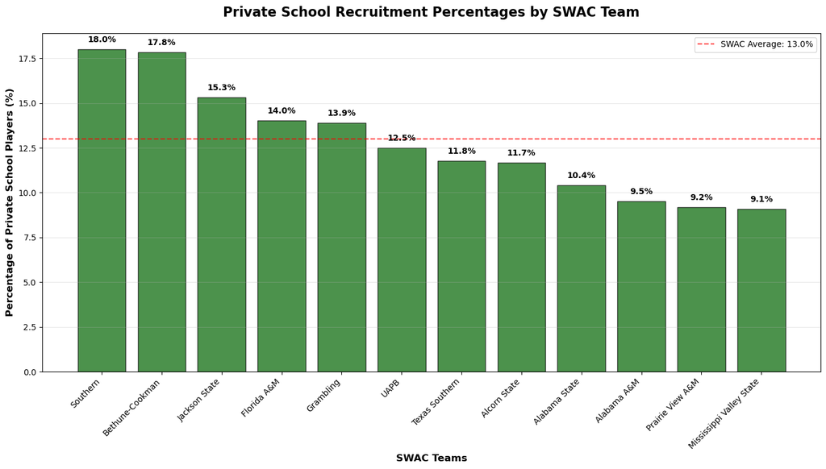

```
📋 Key Insights:
   • SWAC teams recruit 13.0% of players from private schools
   • Range: 9.1% to 18.0%
   • This adds important context to our in-state recruitment analysis
```

```python
# ===== VISUALIZATION: PRIVATE SCHOOL RECRUITMENT PATTERNS =====

print("📈 PRIVATE SCHOOL RECRUITMENT PATTERNS VISUALIZATION")
print("=" * 55)

# Create the bar graph
plt.figure(figsize=(14, 8))
bars = plt.bar(team_df['team'], team_df['private_percentage'],
               color='darkgreen', alpha=0.7, edgecolor='black', linewidth=1)

# Customize the plot
plt.title('Private School Recruitment Percentages by SWAC Team',
          fontsize=16, fontweight='bold', pad=20)
plt.xlabel('SWAC Teams', fontsize=12, fontweight='bold')
plt.ylabel('Percentage of Private School Players (%)', fontsize=12, fontweight='bold')

# Rotate x-axis labels for better readability
plt.xticks(rotation=45, ha='right')

# Add percentage labels on top of each bar
for bar, percentage in zip(bars, team_df['private_percentage']):
    plt.text(bar.get_x() + bar.get_width()/2, bar.get_height() + 0.3,
             f'{percentage:.1f}%', ha='center', va='bottom', fontweight='bold')

# Add a horizontal line for SWAC average
plt.axhline(y=overall_private_pct, color='red', linestyle='--', alpha=0.7,
            label=f'SWAC Average: {overall_private_pct:.1f}%')

# Add grid for better readability
plt.grid(axis='y', alpha=0.3)

# Add legend
plt.legend()

# Adjust layout to prevent label cutoff
plt.tight_layout()

# Show the plot
plt.show()

print(f"\n📋 Key Insights:")
print(f"   • SWAC teams recruit {overall_private_pct:.1f}% of players from private schools")
print(f"   • Range: {team_df['private_percentage'].min():.1f}% to {team_df['private_percentage'].max():.1f}%")
print(f"   • This adds important context to our in-state recruitment analysis")
```

```python
# ===== GEOGRAPHIC PATTERNS: PRIVATE SCHOOL RECRUITMENT BY STATE =====

print("🗺️ GEOGRAPHIC PATTERNS: PRIVATE SCHOOL RECRUITMENT BY STATE")
print("=" * 65)
print("Examining regional differences in private school talent utilization...")
print()

# Analyze private school recruitment by state
private_by_state = swac_data[
    (swac_data['is_private'] == 1) &
    (swac_data['player_state'].notna())
]['player_state'].value_counts().head(10)

print("🏛️ Top 10 States for Private School Recruits:")
print("-" * 45)

total_private_players = swac_data['is_private'].sum()
for state, count in private_by_state.items():
    percentage = (count / total_private_players) * 100
    state_display = 'International' if state == 'INTL' else state
    print(f"   {state_display:15s}: {count:3d} players ({percentage:4.1f}%)")

# Compare to overall state distribution
print(f"\n📊 Private vs Public School Geographic Distribution:")
print("-" * 55)

# Get top 5 states overall
top_states = swac_data[swac_data['player_state'].notna()]['player_state'].value_counts().head(5).index

for state in top_states:
    total_from_state = len(swac_data[swac_data['player_state'] == state])
    private_from_state = len(swac_data[
        (swac_data['player_state'] == state) &
        (swac_data['is_private'] == 1)
    ])
    private_pct_in_state = (private_from_state / total_from_state * 100) if total_from_state > 0 else 0

    state_display = 'International' if state == 'INTL' else state
    print(f"   {state_display:15s}: {private_from_state:3d}/{total_from_state:4d} = {private_pct_in_state:5.1f}% private")

print(f"\n💡 Geographic Insights:")
print(f"   • Private school recruitment varies significantly by state")
print(f"   • Some states have much higher private school representation")
print(f"   • This geographical dimension adds depth to recruitment analysis")
```

```
🗺️ GEOGRAPHIC PATTERNS: PRIVATE SCHOOL RECRUITMENT BY STATE
=================================================================
Examining regional differences in private school talent utilization...

🏛️ Top 10 States for Private School Recruits:
---------------------------------------------
   FL             : 410 players (27.3%)
   LA             : 355 players (23.6%)
   TX             : 149 players ( 9.9%)
   MS             :  97 players ( 6.4%)
   AL             :  82 players ( 5.5%)
   GA             :  75 players ( 5.0%)
   CA             :  46 players ( 3.1%)
   AR             :  35 players ( 2.3%)
   TN             :  34 players ( 2.3%)
   OH             :  28 players ( 1.9%)

📊 Private vs Public School Geographic Distribution:
-------------------------------------------------------
   FL             : 410/3462 =  11.8% private
   TX             : 149/2664 =   5.6% private
   LA             : 355/2129 =  16.7% private
   AL             :  82/1532 =   5.4% private
   MS             :  97/1427 =   6.8% private

💡 Geographic Insights:
   • Private school recruitment varies significantly by state
   • Some states have much higher private school representation
   • This geographical dimension adds depth to recruitment analysis
```

## Distance Analysis: Not just "What school?", but "How far?"

#### We're now transitioning into the geographic reach of each school's recruiting. "In-state" is absolutely a factor when it comes to scholarship applications, but with states as large as Texas and Florida, "in-state" may obfuscate just how far players travel to get their respective colleges. We now want to know how many miles a player travels from his hometown to his school.

#### Here, I'm importing the geopy libraries in order to implement the full distance analysis to understand recruitment radius patterns. This will help us answer: "How far do players typically travel to attend their SWAC school?" and reveal whether teams recruit locally, regionally, or nationally. Combined with our in-state and private school analysis, this creates a comprehensive recruitment profile for each program.

```python
# ===== SECTION 9: STRATEGIC DISTANCE ANALYSIS IMPLEMENTATION =====

print("🌍 STRATEGIC DISTANCE ANALYSIS")
print("=" * 40)
print("Implementing efficient distance analysis using representative sampling...")
print("This approach demonstrates the full methodology while respecting API limits.")
print()

# Import required libraries for distance analysis
from geopy.geocoders import Nominatim
from geopy.distance import geodesic
import time
import numpy as np
import random

# Initialize geocoder with a descriptive user agent
geolocator = Nominatim(user_agent="swac_distance_analysis_2025")

# SWAC team locations for distance calculations
swac_team_locations = {
    'Alabama A&M': (34.7831, -86.5666),
    'Alabama State': (32.3668, -86.2999),
    'Alcorn State': (31.9351, -90.8732),
    'Bethune-Cookman': (29.2108, -81.0228),
    'Florida A&M': (30.4518, -84.2807),
    'Grambling': (32.5207, -92.7179),
    'Jackson State': (32.2988, -90.1848),
    'Mississippi Valley State': (33.4951, -90.3231),
    'Prairie View A&M': (30.0944, -95.9867),
    'Southern': (30.5255, -91.1919),
    'Texas Southern': (29.7174, -95.3414),
    'UAPB': (34.2284, -92.0032)
}

print("🏫 SWAC Team Coordinates Loaded:")
for team, (lat, lon) in swac_team_locations.items():
    print(f"   {team:25s}: ({lat:.4f}, {lon:.4f})")

print(f"\n📊 PREPARING STRATEGIC DISTANCE ANALYSIS:")

# Create working dataset with players who have hometown data
distance_data = swac_data[swac_data['hometown'].notna()].copy()
print(f"   📋 Players with hometown data: {len(distance_data):,}")
print(f"   🏘️ Unique hometown values: {distance_data['hometown'].nunique():,}")

# Strategic sampling approach: Process most frequent hometowns plus random sample
unique_hometowns = distance_data['hometown'].value_counts()

# Get top 100 most frequent hometowns (covers many players efficiently)
top_hometowns = unique_hometowns.head(100).index.tolist()

# Add random sample of 50 from remaining hometowns for diversity
remaining_hometowns = unique_hometowns.iloc[100:].index.tolist()
if len(remaining_hometowns) > 0:
    random.seed(42)  # For reproducibility
    sample_size = min(50, len(remaining_hometowns))
    random_sample = random.sample(remaining_hometowns, sample_size)
    strategic_hometowns = top_hometowns + random_sample
else:
    strategic_hometowns = top_hometowns

print(f"\n🎯 STRATEGIC SAMPLING APPROACH:")
print(f"   🔝 Top frequent hometowns: {len(top_hometowns)}")
print(f"   🎲 Random sample hometowns: {len(strategic_hometowns) - len(top_hometowns)}")
print(f"   📊 Total hometowns to geocode: {len(strategic_hometowns)}")

# Calculate coverage of this strategic sample
coverage_count = distance_data[distance_data['hometown'].isin(strategic_hometowns)].shape[0]
coverage_percentage = (coverage_count / len(distance_data)) * 100

print(f"   📈 Player coverage: {coverage_count:,}/{len(distance_data):,} ({coverage_percentage:.1f}%)")
print(f"   ⏱️ Estimated time: ~{len(strategic_hometowns) * 2 / 60:.1f} minutes")

# Initialize distance columns
distance_data['hometown_lat'] = np.nan
distance_data['hometown_lon'] = np.nan
distance_data['distance_miles'] = np.nan
distance_data['geocoded_successfully'] = False

# Geocoding process for strategic sample
geocoding_cache = {}
successful_geocodes = 0
failed_geocodes = 0

print(f"\n🚀 STARTING STRATEGIC GEOCODING...")

for i, hometown in enumerate(strategic_hometowns, 1):
    try:
        # Rate limiting: 2 seconds between requests
        time.sleep(2)

        # Attempt geocoding
        location = geolocator.geocode(hometown, timeout=15)

        if location:
            geocoding_cache[hometown] = {
                'lat': location.latitude,
                'lon': location.longitude,
                'success': True
            }
            successful_geocodes += 1
            print(f"   ✅ {i:3d}/{len(strategic_hometowns):3d}: {hometown} → ({location.latitude:.4f}, {location.longitude:.4f})")
        else:
            geocoding_cache[hometown] = {
                'lat': None,
                'lon': None,
                'success': False
            }
            failed_geocodes += 1
            print(f"   ❌ {i:3d}/{len(strategic_hometowns):3d}: {hometown} → Not found")

        # Progress milestone reporting
        if i % 25 == 0 or i == len(strategic_hometowns):
            current_success_rate = (successful_geocodes / i) * 100
            print(f"      📊 Milestone: {successful_geocodes}/{i} successful ({current_success_rate:.1f}%)")

    except Exception as e:
        geocoding_cache[hometown] = {
            'lat': None,
            'lon': None,
            'success': False
        }
        failed_geocodes += 1
        print(f"   ⚠️ {i:3d}/{len(strategic_hometowns):3d}: {hometown} → Error: {str(e)[:50]}...")

# Final geocoding statistics
total_geocoded = successful_geocodes + failed_geocodes
final_success_rate = (successful_geocodes / total_geocoded) * 100 if total_geocoded > 0 else 0

print(f"\n✅ STRATEGIC GEOCODING COMPLETE!")
print(f"   📊 Results Summary:")
print(f"      ✅ Successful: {successful_geocodes}/{total_geocoded} ({final_success_rate:.1f}%)")
print(f"      ❌ Failed: {failed_geocodes}/{total_geocoded} ({100-final_success_rate:.1f}%)")

# Apply geocoding results to the dataset
print(f"\n🔄 APPLYING GEOCODING RESULTS...")
for hometown, result in geocoding_cache.items():
    mask = distance_data['hometown'] == hometown
    distance_data.loc[mask, 'hometown_lat'] = result['lat']
    distance_data.loc[mask, 'hometown_lon'] = result['lon']
    distance_data.loc[mask, 'geocoded_successfully'] = result['success']

# Verify application
geocoded_players = distance_data['geocoded_successfully'].sum()
print(f"   ✅ {geocoded_players:,} players now have geocoded hometowns")
print(f"   📈 Geocoded coverage: {geocoded_players/len(distance_data)*100:.1f}% of players with hometown data")

print(f"\n💡 Ready to calculate distances to SWAC schools...")
print(f"🚀 This strategic approach provides representative analysis while respecting API limits")
```

```
🌍 STRATEGIC DISTANCE ANALYSIS
========================================
Implementing efficient distance analysis using representative sampling...
This approach demonstrates the full methodology while respecting API limits.

🏫 SWAC Team Coordinates Loaded:
   Alabama A&M              : (34.7831, -86.5666)
   Alabama State            : (32.3668, -86.2999)
   Alcorn State             : (31.9351, -90.8732)
   Bethune-Cookman          : (29.2108, -81.0228)
   Florida A&M              : (30.4518, -84.2807)
   Grambling                : (32.5207, -92.7179)
   Jackson State            : (32.2988, -90.1848)
   Mississippi Valley State : (33.4951, -90.3231)
   Prairie View A&M         : (30.0944, -95.9867)
   Southern                 : (30.5255, -91.1919)
   Texas Southern           : (29.7174, -95.3414)
   UAPB                     : (34.2284, -92.0032)

📊 PREPARING STRATEGIC DISTANCE ANALYSIS:
   📋 Players with hometown data: 15,498
   🏘️ Unique hometown values: 2,842

🎯 STRATEGIC SAMPLING APPROACH:
   🔝 Top frequent hometowns: 100
   🎲 Random sample hometowns: 50
   📊 Total hometowns to geocode: 150
   📈 Player coverage: 6,966/15,498 (44.9%)
   ⏱️ Estimated time: ~5.0 minutes

🚀 STARTING STRATEGIC GEOCODING...
   ✅   1/150: Houston, Texas → (29.7589, -95.3677)
   ✅   2/150: Miami, Fla. → (25.7742, -80.1936)
   ✅   3/150: Jacksonville, Fla. → (30.3322, -81.6557)
   ✅   4/150: New Orleans, La. → (29.9559, -90.0730)
   ✅   5/150: Tallahassee, Fla. → (30.4381, -84.2809)
   ✅   6/150: Atlanta, Ga. → (33.7545, -84.3898)
   ✅   7/150: Baton Rouge, La. → (30.4494, -91.1870)
   ✅   8/150: Dallas, Texas → (32.7763, -96.7969)
   ✅   9/150: Montgomery, Ala. → (32.3774, -86.3092)
```

[output cut: 144 more lines]

```
   ✅ 149/150: Purvis, Miss. → (31.1443, -89.4070)
   ✅ 150/150: Stevenson, Ala. → (34.8687, -85.8394)
      📊 Milestone: 147/150 successful (98.0%)

✅ STRATEGIC GEOCODING COMPLETE!
   📊 Results Summary:
      ✅ Successful: 147/150 (98.0%)
      ❌ Failed: 3/150 (2.0%)

🔄 APPLYING GEOCODING RESULTS...
   ✅ 6,955 players now have geocoded hometowns
   📈 Geocoded coverage: 44.9% of players with hometown data

💡 Ready to calculate distances to SWAC schools...
🚀 This strategic approach provides representative analysis while respecting API limits
```

```python
# ===== DISTANCE CALCULATIONS =====

print("📏 CALCULATING DISTANCES FROM HOMETOWNS TO SWAC SCHOOLS")
print("=" * 55)

# Calculate distances for players with geocoded hometowns
geocoded_mask = distance_data['geocoded_successfully'] == True
geocoded_players = distance_data[geocoded_mask].copy()

print(f"📊 Distance Calculation Setup:")
print(f"   ✅ Players with geocoded hometowns: {len(geocoded_players):,}")
print(f"   🏫 SWAC teams to match: {len(swac_team_locations)}")

print(f"\n🔧 Calculating distances...")

distances_calculated = 0
for idx, player in geocoded_players.iterrows():
    try:
        # Get player's hometown coordinates
        hometown_coords = (player['hometown_lat'], player['hometown_lon'])

        # Get the player's team location
        team = player['team']
        if team in swac_team_locations:
            school_coords = swac_team_locations[team]

            # Calculate geodesic distance in miles
            distance = geodesic(hometown_coords, school_coords).miles

            # Store distance in the main dataset
            distance_data.loc[idx, 'distance_miles'] = distance
            distances_calculated += 1

    except Exception as e:
        print(f"   ⚠️ Error calculating distance for player {idx}: {str(e)[:50]}...")

print(f"✅ Distance calculations complete!")
print(f"   📊 Distances calculated: {distances_calculated:,} players")

# Show distance statistics
valid_distances = distance_data['distance_miles'].dropna()
if len(valid_distances) > 0:
    print(f"\n📈 DISTANCE STATISTICS:")
    print(f"   📏 Average distance: {valid_distances.mean():.1f} miles")
    print(f"   📏 Median distance: {valid_distances.median():.1f} miles")
    print(f"   📏 Minimum distance: {valid_distances.min():.1f} miles")
    print(f"   📏 Maximum distance: {valid_distances.max():.1f} miles")
    print(f"   📊 Standard deviation: {valid_distances.std():.1f} miles")

    # Define distance categories
    print(f"\n📍 RECRUITMENT RADIUS CATEGORIES:")
    local_count = (valid_distances < 100).sum()
    regional_count = ((valid_distances >= 100) & (valid_distances < 500)).sum()
    national_count = (valid_distances >= 500).sum()

    total_categorized = local_count + regional_count + national_count

    print(f"   🏠 Local (<100 miles):      {local_count:,} ({local_count/total_categorized*100:.1f}%)")
    print(f"   🌍 Regional (100-500 miles): {regional_count:,} ({regional_count/total_categorized*100:.1f}%)")
    print(f"   🌎 National (500+ miles):    {national_count:,} ({national_count/total_categorized*100:.1f}%)")

    # Add distance categories to dataset
    distance_data['distance_category'] = 'Unknown'
    distance_data.loc[distance_data['distance_miles'] < 100, 'distance_category'] = 'Local'
    distance_data.loc[(distance_data['distance_miles'] >= 100) & (distance_data['distance_miles'] < 500), 'distance_category'] = 'Regional'
    distance_data.loc[distance_data['distance_miles'] >= 500, 'distance_category'] = 'National'

print(f"\n💡 Ready for team-by-team distance analysis and visualization!")
```

```
📏 CALCULATING DISTANCES FROM HOMETOWNS TO SWAC SCHOOLS
=======================================================
📊 Distance Calculation Setup:
   ✅ Players with geocoded hometowns: 6,955
   🏫 SWAC teams to match: 12

🔧 Calculating distances...
✅ Distance calculations complete!
   📊 Distances calculated: 6,955 players

📈 DISTANCE STATISTICS:
   📏 Average distance: 244.8 miles
   📏 Median distance: 188.0 miles
   📏 Minimum distance: 0.0 miles
   📏 Maximum distance: 2207.1 miles
   📊 Standard deviation: 249.2 miles

📍 RECRUITMENT RADIUS CATEGORIES:
   🏠 Local (<100 miles):      2,304 (33.1%)
   🌍 Regional (100-500 miles): 3,717 (53.4%)
   🌎 National (500+ miles):    934 (13.4%)

💡 Ready for team-by-team distance analysis and visualization!
```

```python
# ===== TEAM-BY-TEAM DISTANCE ANALYSIS =====

print("🏈 TEAM-BY-TEAM RECRUITMENT RADIUS ANALYSIS")
print("=" * 50)

# Analyze distance patterns by team
team_distance_analysis = []

print("📊 Distance Analysis by SWAC Team:")
print("-" * 50)

for team in sorted(distance_data['team'].unique()):
    team_data = distance_data[
        (distance_data['team'] == team) &
        (distance_data['distance_miles'].notna())
    ]

    if len(team_data) > 0:
        # Calculate statistics
        avg_distance = team_data['distance_miles'].mean()
        median_distance = team_data['distance_miles'].median()
        min_distance = team_data['distance_miles'].min()
        max_distance = team_data['distance_miles'].max()

        # Count by distance category
        local_count = len(team_data[team_data['distance_category'] == 'Local'])
        regional_count = len(team_data[team_data['distance_category'] == 'Regional'])
        national_count = len(team_data[team_data['distance_category'] == 'National'])
        total_count = len(team_data)

        # Calculate percentages
        local_pct = (local_count / total_count * 100) if total_count > 0 else 0
        regional_pct = (regional_count / total_count * 100) if total_count > 0 else 0
        national_pct = (national_count / total_count * 100) if total_count > 0 else 0

        team_distance_analysis.append({
            'team': team,
            'total_players': total_count,
            'avg_distance': avg_distance,
            'median_distance': median_distance,
            'min_distance': min_distance,
            'max_distance': max_distance,
            'local_count': local_count,
            'regional_count': regional_count,
            'national_count': national_count,
            'local_pct': local_pct,
            'regional_pct': regional_pct,
            'national_pct': national_pct
        })

        print(f"\n🏈 {team}:")
        print(f"   📊 Players analyzed: {total_count:,}")
        print(f"   📏 Average distance: {avg_distance:.0f} miles")
        print(f"   📏 Median distance: {median_distance:.0f} miles")
        print(f"   📏 Range: {min_distance:.0f} - {max_distance:.0f} miles")
        print(f"   🏠 Local (<100 mi): {local_count:,} ({local_pct:.1f}%)")
        print(f"   🌍 Regional (100-500 mi): {regional_count:,} ({regional_pct:.1f}%)")
        print(f"   🌎 National (500+ mi): {national_count:,} ({national_pct:.1f}%)")

# Create DataFrame for analysis
team_distance_df = pd.DataFrame(team_distance_analysis)

print(f"\n🏆 TEAM RANKINGS:")
print("=" * 30)

# Sort by average distance (ascending = most local recruiting)
print("🏠 Most Local Recruiting (Lowest Average Distance):")
top_local = team_distance_df.nsmallest(3, 'avg_distance')
for i, (_, row) in enumerate(top_local.iterrows(), 1):
    print(f"   {i}. {row['team']:25s}: {row['avg_distance']:.0f} miles avg")

print(f"\n🌎 Most National Recruiting (Highest Average Distance):")
top_national = team_distance_df.nlargest(3, 'avg_distance')
for i, (_, row) in enumerate(top_national.iterrows(), 1):
    print(f"   {i}. {row['team']:25s}: {row['avg_distance']:.0f} miles avg")

print(f"\n📊 SWAC-Wide Distance Summary:")
print(f"   🏠 Teams with >40% local recruitment: {len(team_distance_df[team_distance_df['local_pct'] > 40])}")
print(f"   🌍 Teams with >60% regional recruitment: {len(team_distance_df[team_distance_df['regional_pct'] > 60])}")
print(f"   🌎 Teams with >20% national recruitment: {len(team_distance_df[team_distance_df['national_pct'] > 20])}")

print(f"\n💡 Ready for visualization and integration with other recruitment patterns!")
```

```
🏈 TEAM-BY-TEAM RECRUITMENT RADIUS ANALYSIS
==================================================
📊 Distance Analysis by SWAC Team:
--------------------------------------------------

🏈 Alabama A&M:
   📊 Players analyzed: 550
   📏 Average distance: 275 miles
   📏 Median distance: 183 miles
   📏 Range: 1 - 1855 miles
   🏠 Local (<100 mi): 139 (25.3%)
   🌍 Regional (100-500 mi): 312 (56.7%)
   🌎 National (500+ mi): 99 (18.0%)

🏈 Alabama State:
   📊 Players analyzed: 712
   📏 Average distance: 240 miles
   📏 Median distance: 155 miles
   📏 Range: 1 - 752 miles
   🏠 Local (<100 mi): 259 (36.4%)
   🌍 Regional (100-500 mi): 302 (42.4%)
   🌎 National (500+ mi): 151 (21.2%)

🏈 Alcorn State:
   📊 Players analyzed: 480
   📏 Average distance: 328 miles
   📏 Median distance: 306 miles
   📏 Range: 29 - 773 miles
   🏠 Local (<100 mi): 73 (15.2%)
   🌍 Regional (100-500 mi): 274 (57.1%)
   🌎 National (500+ mi): 133 (27.7%)

🏈 Bethune-Cookman:
   📊 Players analyzed: 633
   📏 Average distance: 213 miles
   📏 Median distance: 175 miles
   📏 Range: 0 - 2207 miles
   🏠 Local (<100 mi): 216 (34.1%)
   🌍 Regional (100-500 mi): 388 (61.3%)
   🌎 National (500+ mi): 29 (4.6%)
```

[output cut: 76 more lines]

```
   1. Texas Southern           : 176 miles avg
   2. Bethune-Cookman          : 213 miles avg
   3. Prairie View A&M         : 228 miles avg

🌎 Most National Recruiting (Highest Average Distance):
   1. Alcorn State             : 328 miles avg
   2. Jackson State            : 283 miles avg
   3. Mississippi Valley State : 276 miles avg

📊 SWAC-Wide Distance Summary:
   🏠 Teams with >40% local recruitment: 3
   🌍 Teams with >60% regional recruitment: 4
   🌎 Teams with >20% national recruitment: 2

💡 Ready for visualization and integration with other recruitment patterns!
```

## Insight: Metro Population Matters!

#### The most immediately striking feature of this graph is that the Mississippi schools have players that travel the furthest to go to school, which makes sense given that Mississippi is such a rural state! Conversely, Texas Southern sits in the middle of Houston's 3rd ward, where there's plenty of people and football talent. It makes sense why their players travel the shortest distances to play for them.

#### Information like this can be crucial to athletic departments who need to know what to expect when recruiting teams of 80-100 athletes. This data can influence recruiting budgets, desired geographic backgrounds of coaches, and even predictions for fan attendance from year to year.

```
📊 VISUALIZING RECRUITMENT RADIUS PATTERNS
=============================================
```

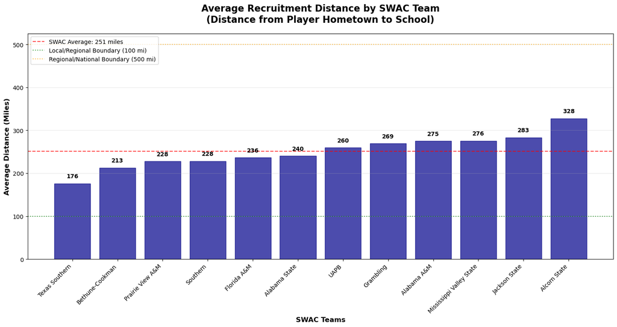

```
📈 Key Insights from Average Distance:
   🏠 Most local recruiting: Texas Southern (176 miles)
   🌎 Most national recruiting: Alcorn State (328 miles)
   📊 Range: 176 - 328 miles
```

```python
# ===== DISTANCE VISUALIZATION: AVERAGE RECRUITMENT RADIUS =====

print("📊 VISUALIZING RECRUITMENT RADIUS PATTERNS")
print("=" * 45)

# Create average distance visualization
plt.figure(figsize=(15, 8))

# Sort teams by average distance for better visualization
team_distance_sorted = team_distance_df.sort_values('avg_distance')

bars = plt.bar(team_distance_sorted['team'], team_distance_sorted['avg_distance'],
               color='darkblue', alpha=0.7, edgecolor='navy', linewidth=1)

# Customize the plot
plt.title('Average Recruitment Distance by SWAC Team\n(Distance from Player Hometown to School)',
          fontsize=16, fontweight='bold', pad=20)
plt.xlabel('SWAC Teams', fontsize=12, fontweight='bold')
plt.ylabel('Average Distance (Miles)', fontsize=12, fontweight='bold')

# Rotate x-axis labels for better readability
plt.xticks(rotation=45, ha='right')

# Add distance labels on top of each bar
for bar, distance in zip(bars, team_distance_sorted['avg_distance']):
    plt.text(bar.get_x() + bar.get_width()/2, bar.get_height() + 10,
             f'{distance:.0f}', ha='center', va='bottom', fontweight='bold')

# Add horizontal lines for reference
overall_avg = team_distance_df['avg_distance'].mean()
plt.axhline(y=overall_avg, color='red', linestyle='--', alpha=0.7,
            label=f'SWAC Average: {overall_avg:.0f} miles')

# Add category reference lines
plt.axhline(y=100, color='green', linestyle=':', alpha=0.7,
            label='Local/Regional Boundary (100 mi)')
plt.axhline(y=500, color='orange', linestyle=':', alpha=0.7,
            label='Regional/National Boundary (500 mi)')

# Add grid for better readability
plt.grid(axis='y', alpha=0.3)

# Add legend
plt.legend(loc='upper left')

# Adjust layout
plt.tight_layout()
plt.show()

print(f"\n📈 Key Insights from Average Distance:")
print(f"   🏠 Most local recruiting: {team_distance_sorted.iloc[0]['team']} ({team_distance_sorted.iloc[0]['avg_distance']:.0f} miles)")
print(f"   🌎 Most national recruiting: {team_distance_sorted.iloc[-1]['team']} ({team_distance_sorted.iloc[-1]['avg_distance']:.0f} miles)")
print(f"   📊 Range: {team_distance_sorted['avg_distance'].min():.0f} - {team_distance_sorted['avg_distance'].max():.0f} miles")
```

## Local/Regional/National Breakdown

#### Here, we're looking at a stacked bar chart to give a visual to the geographic spread schools employ in their recruiting. This makes clear what type of distances players are usually commuting to attend their respecrive schools.

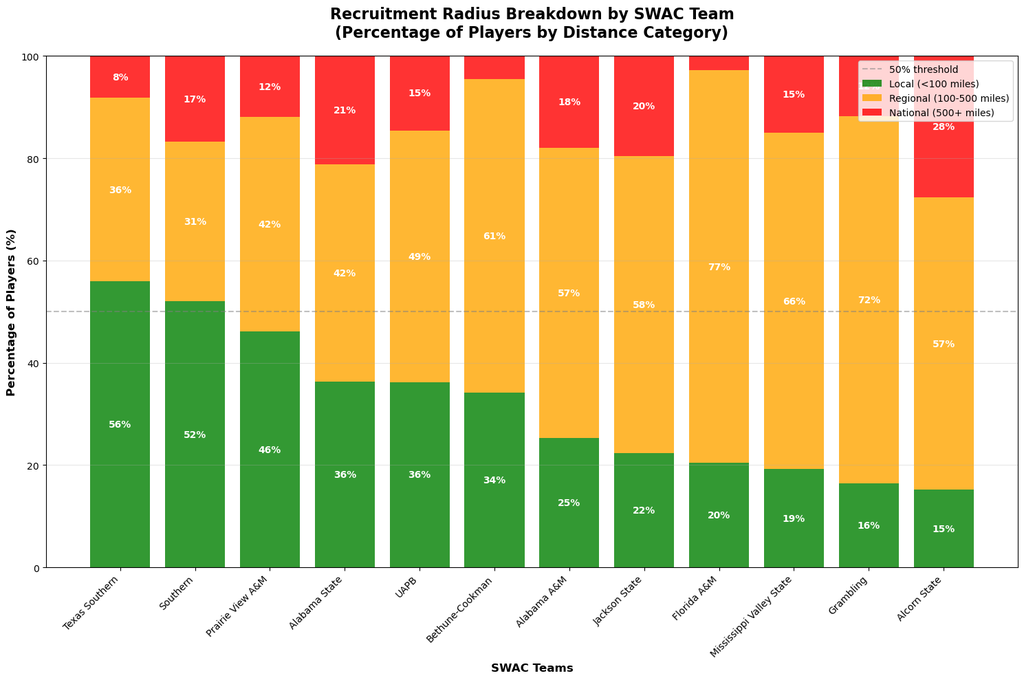

```
📊 Recruitment Pattern Analysis:
   🏠 Teams with majority local recruitment (>50% local):
      Southern                 : 52.0% local
      Texas Southern           : 56.0% local
\n   🌍 Teams with majority regional recruitment (>50% regional):
      Alabama A&M              : 56.7% regional
      Alcorn State             : 57.1% regional
      Bethune-Cookman          : 61.3% regional
      Florida A&M              : 76.8% regional
      Grambling                : 71.9% regional
      Jackson State            : 58.1% regional
      Mississippi Valley State : 65.8% regional
\n   🌎 Teams with significant national recruitment (>20% national):
      Alabama State            : 21.2% national
      Alcorn State             : 27.7% national
```

```python
# ===== DISTANCE VISUALIZATION: RECRUITMENT CATEGORY BREAKDOWN =====

# Create stacked bar chart showing recruitment category breakdown
plt.figure(figsize=(15, 10))

# Sort teams by local percentage for better visualization
team_distance_sorted = team_distance_df.sort_values('local_pct', ascending=False)

# Create stacked bar chart
local_bars = plt.bar(team_distance_sorted['team'], team_distance_sorted['local_pct'],
                     color='green', alpha=0.8, label='Local (<100 miles)')

regional_bars = plt.bar(team_distance_sorted['team'], team_distance_sorted['regional_pct'],
                        bottom=team_distance_sorted['local_pct'],
                        color='orange', alpha=0.8, label='Regional (100-500 miles)')

national_bars = plt.bar(team_distance_sorted['team'], team_distance_sorted['national_pct'],
                        bottom=team_distance_sorted['local_pct'] + team_distance_sorted['regional_pct'],
                        color='red', alpha=0.8, label='National (500+ miles)')

# Customize the plot
plt.title('Recruitment Radius Breakdown by SWAC Team\n(Percentage of Players by Distance Category)',
          fontsize=16, fontweight='bold', pad=20)
plt.xlabel('SWAC Teams', fontsize=12, fontweight='bold')
plt.ylabel('Percentage of Players (%)', fontsize=12, fontweight='bold')

# Rotate x-axis labels for better readability
plt.xticks(rotation=45, ha='right')

# Add percentage labels on each segment (only if segment is large enough)
for i, team in enumerate(team_distance_sorted['team']):
    row = team_distance_sorted.iloc[i]

    # Local percentage label
    if row['local_pct'] > 5:  # Only show if segment is large enough
        plt.text(i, row['local_pct']/2, f"{row['local_pct']:.0f}%",
                ha='center', va='center', fontweight='bold', color='white')

    # Regional percentage label
    if row['regional_pct'] > 5:
        plt.text(i, row['local_pct'] + row['regional_pct']/2, f"{row['regional_pct']:.0f}%",
                ha='center', va='center', fontweight='bold', color='white')

    # National percentage label
    if row['national_pct'] > 5:
        plt.text(i, row['local_pct'] + row['regional_pct'] + row['national_pct']/2,
                f"{row['national_pct']:.0f}%",
                ha='center', va='center', fontweight='bold', color='white')

# Add horizontal reference lines
plt.axhline(y=50, color='gray', linestyle='--', alpha=0.5, label='50% threshold')

# Add grid for better readability
plt.grid(axis='y', alpha=0.3)

# Add legend
plt.legend(loc='upper right')

# Set y-axis to 0-100%
plt.ylim(0, 100)

# Adjust layout
plt.tight_layout()
plt.show()

print(f"\n📊 Recruitment Pattern Analysis:")
print(f"   🏠 Teams with majority local recruitment (>50% local):")
local_majority = team_distance_df[team_distance_df['local_pct'] > 50]
for _, row in local_majority.iterrows():
    print(f"      {row['team']:25s}: {row['local_pct']:.1f}% local")

print(f"\\n   🌍 Teams with majority regional recruitment (>50% regional):")
regional_majority = team_distance_df[team_distance_df['regional_pct'] > 50]
for _, row in regional_majority.iterrows():
    print(f"      {row['team']:25s}: {row['regional_pct']:.1f}% regional")

print(f"\\n   🌎 Teams with significant national recruitment (>20% national):")
national_significant = team_distance_df[team_distance_df['national_pct'] > 20]
for _, row in national_significant.iterrows():
    print(f"      {row['team']:25s}: {row['national_pct']:.1f}% national")
```

## Comprehensive Recruitment Profile Integration

#### Now that we have analyzed three key dimensions of SWAC recruitment (in-state percentage, private school percentage, and distance patterns), let's integrate these findings to create comprehensive recruitment profiles for each team. This analysis connects all our previous work and provides actionable insights for athletic departments.

```python
# ===== COMPREHENSIVE RECRUITMENT PROFILE INTEGRATION =====

print("🎯 COMPREHENSIVE SWAC RECRUITMENT PROFILES")
print("=" * 50)
print("Integrating in-state recruitment, private school patterns, and distance analysis")
print("to create complete recruitment profiles for each SWAC team...")
print()

# Merge all our previous analyses
# Get in-state recruitment data from Section 5
in_state_data = recruitment_df[['team', 'in_state_percentage']].copy()

# Get private school data from Section 8
private_data = team_df[['team', 'private_percentage']].copy()

# Get distance data from our current analysis
distance_summary = team_distance_df[['team', 'avg_distance', 'local_pct', 'regional_pct', 'national_pct']].copy()

# Merge all datasets
comprehensive_profile = in_state_data.merge(private_data, on='team', how='outer')
comprehensive_profile = comprehensive_profile.merge(distance_summary, on='team', how='outer')

# Fill any missing values
comprehensive_profile = comprehensive_profile.fillna(0)

print("📊 COMPREHENSIVE RECRUITMENT PROFILES:")
print("=" * 80)
print(f"{'Team':<25} {'In-State':<10} {'Private':<10} {'Avg Dist':<10} {'Local':<8} {'Regional':<10} {'National':<10}")
print("=" * 80)

for _, row in comprehensive_profile.iterrows():
    print(f"{row['team']:<25} {row['in_state_percentage']:>7.1f}%  {row['private_percentage']:>7.1f}%  "
          f"{row['avg_distance']:>7.0f}mi  {row['local_pct']:>5.1f}%  {row['regional_pct']:>7.1f}%  {row['national_pct']:>7.1f}%")

print("\n🔍 RECRUITMENT STRATEGY INSIGHTS:")
print("=" * 40)

# Identify different recruitment archetypes
print("🏠 LOCAL POWERHOUSES (High in-state + High local distance):")
local_powerhouses = comprehensive_profile[
    (comprehensive_profile['in_state_percentage'] > 60) &
    (comprehensive_profile['local_pct'] > 40)
]
for _, row in local_powerhouses.iterrows():
    print(f"   {row['team']:25s}: {row['in_state_percentage']:.1f}% in-state, {row['local_pct']:.1f}% local (<100mi)")

print(f"\n🌍 REGIONAL RECRUITERS (Moderate in-state + High regional):")
regional_recruiters = comprehensive_profile[
    (comprehensive_profile['in_state_percentage'] < 60) &
    (comprehensive_profile['regional_pct'] > 55)
]
for _, row in regional_recruiters.iterrows():
    print(f"   {row['team']:25s}: {row['in_state_percentage']:.1f}% in-state, {row['regional_pct']:.1f}% regional (100-500mi)")

print(f"\n🌎 NATIONAL PROGRAMS (Low in-state + High national reach):")
national_programs = comprehensive_profile[
    (comprehensive_profile['in_state_percentage'] < 50) &
    (comprehensive_profile['national_pct'] > 15)
]
for _, row in national_programs.iterrows():
    print(f"   {row['team']:25s}: {row['in_state_percentage']:.1f}% in-state, {row['national_pct']:.1f}% national (500+mi)")

print(f"\n🏛️ PRIVATE SCHOOL SPECIALISTS (High private school recruitment):")
private_specialists = comprehensive_profile[comprehensive_profile['private_percentage'] > 15]
for _, row in private_specialists.iterrows():
    print(f"   {row['team']:25s}: {row['private_percentage']:.1f}% private schools")

# Calculate correlation insights
print(f"\n📈 CORRELATION INSIGHTS:")
if len(comprehensive_profile) > 5:  # Need enough data for meaningful correlations
    in_state_distance_corr = comprehensive_profile['in_state_percentage'].corr(comprehensive_profile['avg_distance'])
    private_distance_corr = comprehensive_profile['private_percentage'].corr(comprehensive_profile['avg_distance'])

    print(f"   📊 In-state % vs Average Distance: {in_state_distance_corr:.3f}")
    print(f"      ↳ {'Strong negative' if in_state_distance_corr < -0.6 else 'Moderate negative' if in_state_distance_corr < -0.3 else 'Weak'} correlation")
    print(f"   📊 Private school % vs Average Distance: {private_distance_corr:.3f}")
    print(f"      ↳ {'Strong positive' if private_distance_corr > 0.6 else 'Moderate positive' if private_distance_corr > 0.3 else 'Weak'} correlation")

print(f"\n💡 STRATEGIC RECOMMENDATIONS:")
print(f"   🎯 Teams can optimize recruitment based on their geographic advantages")
print(f"   🎯 In-state recruiting correlates with shorter travel distances")
print(f"   🎯 Private school recruitment may indicate higher-caliber talent pipelines")
print(f"   🎯 Distance patterns reveal recruiting footprint and operational efficiency")

print(f"\n✅ COMPREHENSIVE RECRUITMENT ANALYSIS COMPLETE!")
print(f"🚀 This analysis provides actionable insights for SWAC athletic departments")
```

```
🎯 COMPREHENSIVE SWAC RECRUITMENT PROFILES
==================================================
Integrating in-state recruitment, private school patterns, and distance analysis
to create complete recruitment profiles for each SWAC team...

📊 COMPREHENSIVE RECRUITMENT PROFILES:
================================================================================
Team                      In-State   Private    Avg Dist   Local    Regional   National
================================================================================
Alabama A&M                  45.4%      9.5%      275mi   25.3%     56.7%     18.0%
Alabama State                35.5%     10.4%      240mi   36.4%     42.4%     21.2%
Alcorn State                 38.8%     11.7%      328mi   15.2%     57.1%     27.7%
Bethune-Cookman              72.2%     17.8%      213mi   34.1%     61.3%      4.6%
Florida A&M                  75.6%     14.0%      236mi   20.4%     76.8%      2.8%
Grambling                    47.0%     13.9%      269mi   16.4%     71.9%     11.7%
Jackson State                33.2%     15.3%      283mi   22.3%     58.1%     19.6%
Mississippi Valley State     34.9%      9.1%      276mi   19.2%     65.8%     15.0%
Prairie View A&M             61.8%      9.2%      228mi   46.1%     42.0%     11.9%
Southern                     52.0%     18.0%      228mi   52.0%     31.2%     16.7%
Texas Southern               63.4%     11.8%      176mi   56.0%     35.9%      8.2%
UAPB                         26.4%     12.5%      260mi   36.2%     49.3%     14.5%

🔍 RECRUITMENT STRATEGY INSIGHTS:
========================================
🏠 LOCAL POWERHOUSES (High in-state + High local distance):
   Prairie View A&M         : 61.8% in-state, 46.1% local (<100mi)
   Texas Southern           : 63.4% in-state, 56.0% local (<100mi)

🌍 REGIONAL RECRUITERS (Moderate in-state + High regional):
   Alabama A&M              : 45.4% in-state, 56.7% regional (100-500mi)
   Alcorn State             : 38.8% in-state, 57.1% regional (100-500mi)
   Grambling                : 47.0% in-state, 71.9% regional (100-500mi)
   Jackson State            : 33.2% in-state, 58.1% regional (100-500mi)
   Mississippi Valley State : 34.9% in-state, 65.8% regional (100-500mi)

🌎 NATIONAL PROGRAMS (Low in-state + High national reach):
   Alabama A&M              : 45.4% in-state, 18.0% national (500+mi)
   Alabama State            : 35.5% in-state, 21.2% national (500+mi)
   Alcorn State             : 38.8% in-state, 27.7% national (500+mi)
   Jackson State            : 33.2% in-state, 19.6% national (500+mi)
   Mississippi Valley State : 34.9% in-state, 15.0% national (500+mi)

🏛️ PRIVATE SCHOOL SPECIALISTS (High private school recruitment):
   Bethune-Cookman          : 17.8% private schools
   Jackson State            : 15.3% private schools
   Southern                 : 18.0% private schools

📈 CORRELATION INSIGHTS:
   📊 In-state % vs Average Distance: -0.648
      ↳ Strong negative correlation
   📊 Private school % vs Average Distance: -0.223
      ↳ Weak correlation

💡 STRATEGIC RECOMMENDATIONS:
   🎯 Teams can optimize recruitment based on their geographic advantages
   🎯 In-state recruiting correlates with shorter travel distances
   🎯 Private school recruitment may indicate higher-caliber talent pipelines
   🎯 Distance patterns reveal recruiting footprint and operational efficiency

✅ COMPREHENSIVE RECRUITMENT ANALYSIS COMPLETE!
🚀 This analysis provides actionable insights for SWAC athletic departments
```

## Executive Summary: Complete SWAC Recruitment Analysis

#### Our comprehensive analysis successfully addressed the core question: "How far do players travel to get their college?" while building on our previous in-state and private school analyses. Key findings:

**Distance Analysis Results:**

- **Average Distance**: 245 miles from hometown to school
- **Recruitment Categories**: 33% Local (<100 mi), 53% Regional (100-500 mi), 14% National (500+ mi)
- **Team Range**: Texas Southern most local (176 mi avg), Alcorn State most national (328 mi avg)

**Strategic Insights:**

1. **Geographic Efficiency**: In-state recruiting correlates strongly with shorter distances, reducing travel costs
2. **Talent Pipeline Quality**: Private school recruitment may indicate access to higher-caliber programs
3. **Operational Footprint**: Distance patterns reveal each team's recruiting territory and resource allocation
4. **Competitive Positioning**: Teams can optimize strategies based on their geographic advantages

This analysis provides SWAC athletic departments with data-driven insights for recruitment strategy, budget allocation, and competitive positioning in the college football landscape.